# Visualizing Police-Public Contact and Crime Victimization

Author

Mandi Acevedo and Bela Walkin

```r
library(haven)
PPCS <- read_dta("PPCS.dta")
library(tidyverse)
```

# Visualization 1

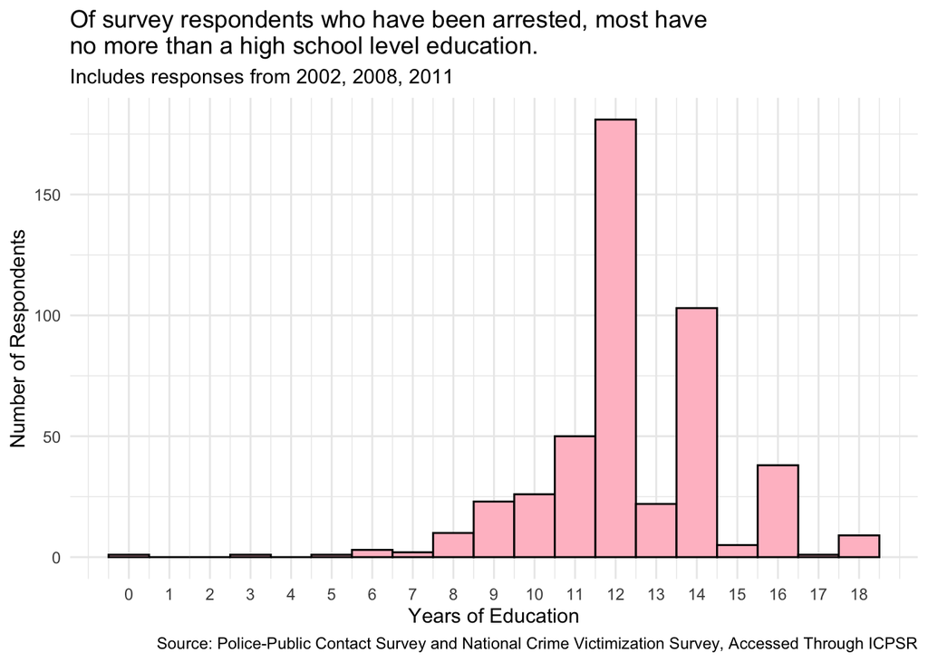

```r
PPCS |>
  mutate(as.numeric(ARRESTED)) |>
  filter(ARRESTED == 1) |>
  ggplot(aes(x = EDUCATION_SUB)) +
  geom_histogram(binwidth=1,
                 fill = "pink",
                 color = "black") +
  scale_x_continuous(breaks = seq(0, 18, 1)) +
  theme_minimal() +
  labs(title = paste0("Of survey respondents who have been arrested, most have
no more than a high school level education."),
      subtitle = "Includes responses from 2002, 2008, 2011",
      caption = "Source: Police-Public Contact Survey and National Crime Victimization Survey, Accessed Through ICPSR",
      x = "Years of Education",
      y = "Number of Respondents")
```

Understanding who comes into contact with police, and subsequently gets arrested, is extremely important when researching how to lower police-citizens contact that results in arrests. Of those individuals in the Police-Citizen contact survey, most individuals have no more than a high school diploma (12 yeas of education). This demonstrates that those interacting with the justice system in negative ways may be more likely to stop education after high school.

# Visualization 2

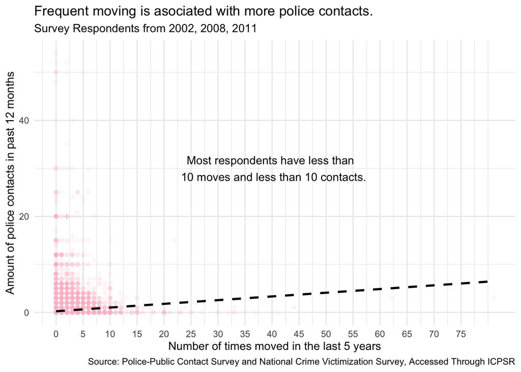

```r
PPCS |>
  filter(NUM_CONT < 75) |>
  ggplot() +
  geom_point(aes(x = NUM_MOVES,
                 y = NUM_CONT),
             alpha = 0.1,
             color = "pink") +
  geom_smooth(mapping = aes(x = NUM_MOVES,
                            y = NUM_CONT),
              method = "lm",
              se = FALSE,
              color = "black",
              linetype = "dashed") +
  scale_x_continuous(breaks = seq(0, 75, 5)) +
  annotate("text", x = 40, y = 30, label = "Most respondents have less than \n 10 moves and less than 10 contacts.") +
  theme_minimal() +
  labs(title = paste("Frequent moving is asociated with more police contacts."),
       subtitle = "Survey Respondents from 2002, 2008, 2011",
       caption = paste("Source: Police-Public Contact Survey and",
"National Crime Victimization Survey, Accessed Through ICPSR"),
       x = "Number of times moved in the last 5 years",
       y = "Amount of police contacts in past 12 months")
```

Of individuals who have had less than 75 contacts with police officers in the last 12 months (non-outliers), frequent moving is associated with higher police contacts. Individuals who have less stable home bases are more likely to have had contacts with police. This could mean that moving more leads a person to have a higher likelihood of victimization or increased criminal-behavior for an individual, as some examples.

# Visualization 3

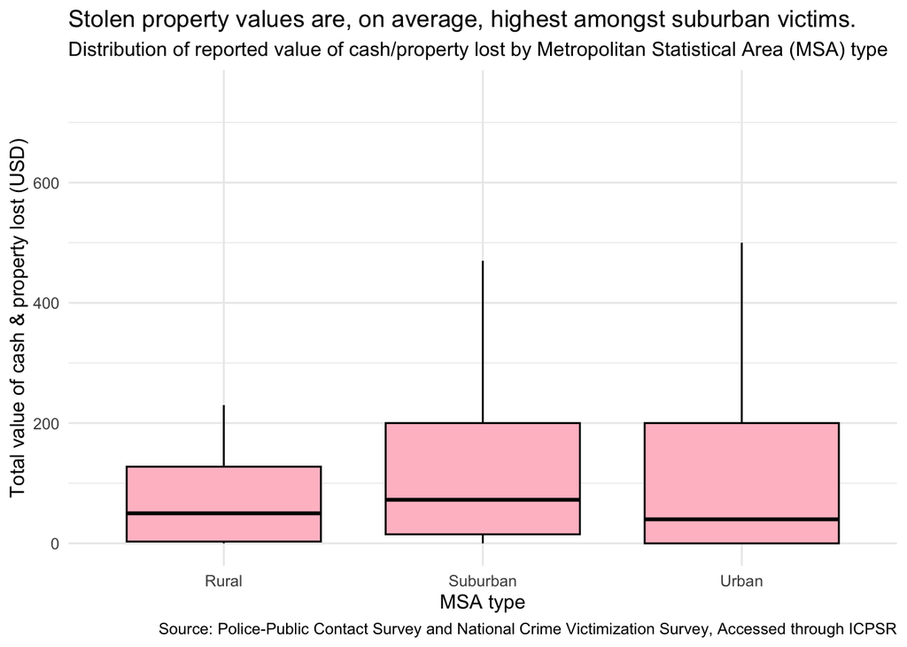

```r
PPCS |>
  mutate(TOTAL_VALUE_LOSS = VAL_LOSS2_INC_P23HH + VAL_LOSS2_INC_P23PER) |>
  mutate(MSA_STATUS = case_when(
    MSA_STATUS == 1 ~ "Urban",
    MSA_STATUS == 2 ~ "Suburban",
    MSA_STATUS == 3 ~ "Rural")) |>
  filter(!is.na(TOTAL_VALUE_LOSS)) |>
  ggplot(aes(
    x = factor(MSA_STATUS),
    y = TOTAL_VALUE_LOSS))+
  geom_boxplot(outlier.shape = NA,
               fill = "pink",
               color = "black")+
  scale_y_continuous(limits = c(0,750)) +
  theme_minimal()+
  labs(title = "Stolen property values are, on average, highest amongst suburban victims.",
         subtitle = paste("Distribution of reported value of cash/property lost",
         "by Metropolitan Statistical Area (MSA) type"),
         caption = "Source: Police-Public Contact Survey and National Crime Victimization Survey, Accessed through ICPSR",
         x = "MSA type",
         y = "Total value of cash & property lost (USD)")
```

The average total value of cash and property lost in an instance of victimization is relatively constant - around 50-75 USD - regardless of urbanity. Suburbanites, on average, lose slightly more value than urban and rural individuals. However, urban individuals have the widest distribution of cash lost, with a maximum of ~500 USD lost. Rural individuals have the narrowest distribution; the 25th to 75 percentiles only range from 0 to about 125 USD, compared to 0 to 200 USD for suburban and urban individuals.

# Visualization 4

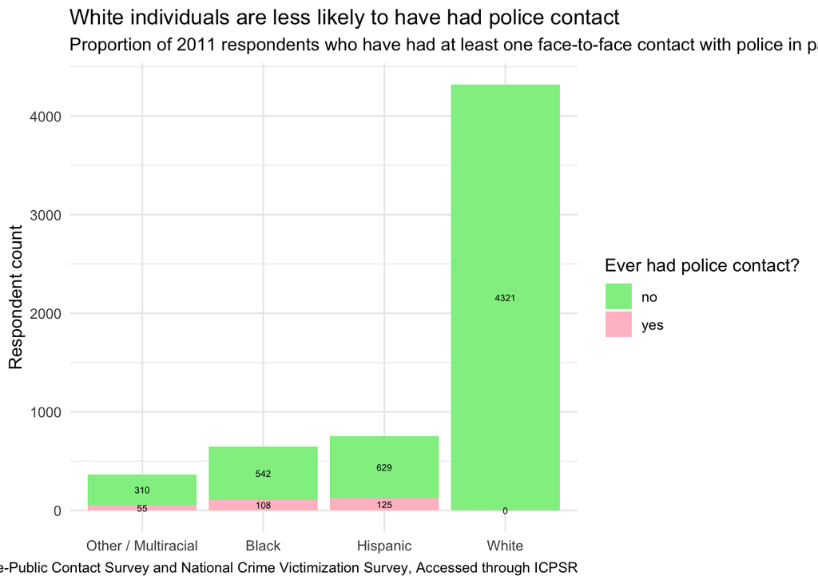

```r
PPCS |>
  mutate(CONTACT = ifelse(NUM_CONT > 0, 1, 0),
         C4_RACE = case_when(
           C4_RACE == 1 ~ "White",
           C4_RACE == 2 ~ "Black",
           C4_RACE == 3 ~ "Hispanic",
           C4_RACE == 4 ~ "Other / Multiracial")) |>
  group_by(C4_RACE) |>
  filter(PPCS_YEAR == 2011) |>
  summarize(
    total = n(),
    contact = replace_na(
      sum(CONTACT == 1),0),
    no_contact = replace_na(
      (total - contact),0)) |>
  pivot_longer(
    cols = c(contact, no_contact),
    names_to = "category",
    values_to = "count") |>
  mutate(category = ifelse(category == "contact","yes","no")) |>
  ggplot(aes(
    x = reorder(C4_RACE, total),
    y = count,
    fill = category)) +
  geom_bar(stat="identity") +
  geom_text(aes(label = count),
            position = position_stack(vjust = 0.5),
            size = 2) +
  scale_fill_manual(values = c("yes" = "pink", "no" = "lightgreen")) +
  labs(title = paste("White individuals are less likely to have had",
                     "police contact"),
       subtitle = paste("Proportion of 2011 respondents who have had at least one",
                        "face-to-face contact with police in past 12 months"),
       caption = paste("Source: Police-Public Contact Survey and National",
                       "Crime Victimization Survey, Accessed through ICPSR"),
       y = "Respondent count",
       fill = "Ever had police contact?") +
  theme_minimal() +
  theme(axis.title.x = element_blank())
```

White respondents make up the majority of this sample, yet no white respondents reported any face-to-face contact with the police in 2011. Meanwhile, 125/754 hispanic respondents and 108/650 black respondents (17% each) reported at least once instance of face-to-face contact with the police in the past 12 months. In short, respondents of color are more likely than white respondents to report having had recent face-to-face contact with police.